# Uber Pickups in NYC (Dynamic Inventory Management)

### Introduction

Imagine that you are a data scientist at a company that has to perform dynamic inventory management. An example of that would be a ride-sharing company where you want to know which parts of a city to direct your drivers to depending on the time of day and other factors like the weather.

Here we’ll perform an analysis and then publish these findings as an easily-consumable Report for collaborators and business users.

### Load data

The data is in data/processed_uber_nyc.RData and contains two dataframes:

1. `agg_data`
2. `zone_polys`

### About the data

The source of the data for this exercise is the [Uber Pickups in New York City dataset by FiveThirtyEight](https://www.kaggle.com/fivethirtyeight/uber-pickups-in-new-york-city). Pickup data for 20 million pickeups are aggregated by hour, date, and taxi zone (i.e., an approximate neighborhood) and enriched with calendar and weather data. More detailed information about each dataframe is below.

#### agg_data

This dataframe contains information about the number of pickups.

Fields:

- `locationID`: unique ID for each taxi zone
- `date`
- `hour`: 24H format
- `borough`: Borough that the zone is located in (e.g. Manhattan, Boorklyn, Queens)
- `zone`: Name of the taxi zone (e.g. Times Sq, Chinatown, Central Harlem)
- `picksups`: Number of pickups
- `day`: Day of week (e.g. Mon, Tue, Wed)
- `is_holiday`: Whether that day was a holiday (Boolean)
- `mean_temp_F`: Mean temperature that day in Fahrenheit

```
## # A tibble: 3 x 9
## # Groups:   locationID, date, hour, borough [3]
##   locationID       date  hour borough           zone pickups   day
##        <int>      <chr> <chr>  <fctr>         <fctr>   <int> <chr>
## 1          1 2014-04-01    03     EWR Newark Airport       2   Tue
## 2          1 2014-04-01    04     EWR Newark Airport       4   Tue
## 3          1 2014-04-01    05     EWR Newark Airport       4   Tue
## # ... with 2 more variables: is_holiday <lgl>, mean_temp_F <int>
```

#### zone_polys

This is a dimension table that describes the boundaries of each taxi zone.

Fields:

- `long`: Longitude
- `lat`: Latitude
- `order`: Rank of point when drawing boundary
- `hole`: Whether to plot a hole in that location (Boolean)
- `piece`: The piece of the zone that the point is associated with
- `id`: ID of zone. Same as locationID in agg_data
- `group`: Group that the point belongs to

```
##        long      lat order  hole piece id group
## 1 -74.18445 40.69500     1 FALSE     1  1   0.1
## 2 -74.18449 40.69509     2 FALSE     1  1   0.1
## 3 -74.18450 40.69518     3 FALSE     1  1   0.1
```

### Exploratory analysis

#### What areas experience the highest demand?

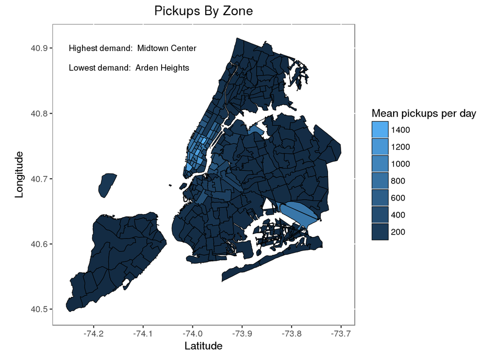